# OSL Factorial ANOVA in R Using Data from Zhang et al. (2014)

Cory J. Cascalheira

December 3, 2018

# Open Stats Lab

Kevin P. McIntyre developed this amazing resource for students of psychology. Check out [Open Stats Lab](https://sites.trinity.edu/osl/) for a collection of all activities.

Each activity includes an article from *Psychological Science*, a data set, and an activity to complete in SPSS. However, if you are an open source fanatic, you could also complete the activity in [JASP](https://jasp-stats.org/). For tips on how to use JASP, check out [this resource](https://osf.io/t56kg/) created by Buchanan, Hopke, and Donaldson (2018).

I prefer to get my hands deep into the data. Dr. McIntyre does not *yet* offer an R activity to accompany the work of [Zhang et al. (2014)](https://journals.sagepub.com/stoken/default+domain/2CauuvIqpaIUiIdXSWh4/full), so here is one possible solution written in R.

# Analysis

I will perform assumption checks for each test prior to running it. We already know that the data meet all assumptions, otherwise the authors would have used a different analytic approach. However, checking the assumptions is helpful because:

1. reproducibility and accuracy can be verified; and
2. if you are a student, then you should form the habit of testing assumptions.

This analysis will follow the data science workflow advocated by [Garrett Grolemund and Hadley Wickham](https://r4ds.had.co.nz/introduction.html). First, we will set-up our session and import the data. Then, we must clean the data. Next, we will transform, model, and visualize the data to understand it. Finally, we will communicate our findings.

## Import

Let’s load the packages necessary for this analysis into our workspace.

```r
library(psych) # describe data
library(broom) # coefficient-level information
library(car) # Levene's test, Anova function
library(nlme) # repeated measures ANOVA
library(multcomp) # post-hoc measures
library(tidyverse) # utility and visualization
```

We can import the dataset using a relative path because our working directory is set.

```r
zhang <- read_csv("../data/Zhang et al. 2014 Study 3.csv")
```

## Clean

What do the data look like?

```r
glimpse(zhang)
```

```
## Observations: 130
## Variables: 35
## $ Condition                       <dbl> 1, 1, 1, 1, 1, 1, 1, 1, 1, 1, ...
## $ T1_Extraordinariness            <dbl> 1, 3, 1, 1, 5, 2, 2, 3, 4, 6, ...
## $ T2_Extraordinariness            <dbl> 5, 2, 4, 3, 6, 2, 5, 4, 5, 2, ...
## $ T1_Predicted_Curious            <dbl> 4, 2, 4, 1, 7, 4, 4, 4, 3, 3, ...
## $ T2_Actual_Curious               <dbl> 5, 2, 2, 2, 7, 7, 4, 5, 4, 6, ...
## $ T1_Predicted_Interest_Composite <dbl> 3.25, 2.00, 5.00, 2.25, 6.50, ...
## $ T2_Actual_Interest_Composite    <dbl> 4.50, 1.50, 6.50, 4.00, 7.00, ...
## $ T2_Detailed                     <dbl> 7, 2, 6, 7, 7, 1, 3, 6, 4, 7, ...
## $ T2_Memory                       <dbl> 2, 13, 17, 40, 61, 75, 29, 50,...
## $ Amount_Underestimated_Interest  <dbl> 1.25, -0.50, 1.50, 1.75, 0.50,...
## $ T1_Ord_PredT2_Curious           <dbl> 4, 2, 4, 1, 7, 4, 4, 4, 3, 3, ...
## $ T1_Ord_PredT2_Enjoy             <dbl> 1, 2, 4, 2, 7, 6, 4, 5, 3, 4, ...
## $ T1_Ord_PredT2_Interesting       <dbl> 4, 2, 6, 3, 7, 6, 6, 6, 5, 4, ...
```

[output cut: 22 more lines]

For this analysis, we only need the first seven variables. Let’s `select()` them using `snake_case` and abbreviation. Since repeated measures ANOVA treats each subject as a factor, we need to add an additional variable to identify the participants.

```r
zhang_clean <- zhang %>%
  select(
    condition = Condition,
    t1_extra = T1_Extraordinariness,
    t2_extra = T2_Extraordinariness,
    t1_curious = T1_Predicted_Curious,
    t2_curious = T2_Actual_Curious,
    t1_interest = T1_Predicted_Interest_Composite,
    t2_interest = T2_Actual_Interest_Composite
  ) %>%
  mutate(subject_id = seq(1, 130, 1))
```

Make `condition` a between-subjects factor with appropriate labels. Since the ordinary condition is mentioned first throughout the article, we can assume that 1 corresponds to ordinary. If our analyses do not match those reported in the paper, then it will be important to return to this step.

Also, transform `subject_id` into a factor in which every level is an individual participant.

```r
zhang_clean <- within(zhang_clean, {
  condition <- factor(condition, labels = c("ordinary", "extraordinary"))
  subject_id <- factor(subject_id)
})
```

How many participants are in each condition?

```r
zhang_clean %>% count(condition)
```

```
## # A tibble: 2 x 2
##   condition         n
##   <fct>         <int>
## 1 ordinary         64
## 2 extraordinary    66
```

Thus, we have an unbalanced design. This will affect our analytic approach.

Let’s split the data by condition to calculate the standard error later with `psych::describe`.

```r
ordinary <- zhang_clean %>% filter(condition == "ordinary")
extraordinary <- zhang_clean %>% filter(condition == "extraordinary")
```

Finally, in order to conduct a repeated measures ANOVA with a continuous dependent measure, time as the within-subjects factor, and condition as the between-subjects factor, it is imperative that we transform the data frame into long format.

```r
long_extra <- zhang_clean %>%
  select(condition, subject_id, t1_extra, t2_extra) %>%
  gather(key = extra_time, value = extra_rating, -c(condition, subject_id))

long_curious <- zhang_clean %>%
  select(t1_curious, t2_curious) %>%
  gather(key = curious_time, value = curious_rating)

long_interest <- zhang_clean %>%
  select(t1_interest, t2_interest) %>%
  gather(key = interest_time, value = interest_rating)

(zhang_long <- bind_cols(long_extra, long_curious, long_interest))
```

```
## # A tibble: 260 x 8
##    condition subject_id extra_time extra_rating curious_time curious_rating
##    <fct>     <fct>      <chr>             <dbl> <chr>                 <dbl>
##  1 ordinary  1          t1_extra              1 t1_curious                4
##  2 ordinary  2          t1_extra              3 t1_curious                2
##  3 ordinary  3          t1_extra              1 t1_curious                4
##  4 ordinary  4          t1_extra              1 t1_curious                1
##  5 ordinary  5          t1_extra              5 t1_curious                7
##  6 ordinary  6          t1_extra              2 t1_curious                4
##  7 ordinary  7          t1_extra              2 t1_curious                4
##  8 ordinary  8          t1_extra              3 t1_curious                4
##  9 ordinary  9          t1_extra              4 t1_curious                3
## 10 ordinary  10         t1_extra              6 t1_curious                3
## # ... with 250 more rows, and 2 more variables: interest_time <chr>,
## #   interest_rating <dbl>
```

The new variables with the suffix `_time` must become factors.

```r
(zhang_long <- within(zhang_long, {
  extra_time <- factor(extra_time)
  curious_time <- factor(curious_time)
  interest_time <- factor(interest_time)
}))
```

```
## # A tibble: 260 x 8
##    condition subject_id extra_time extra_rating curious_time curious_rating
##    <fct>     <fct>      <fct>             <dbl> <fct>                 <dbl>
##  1 ordinary  1          t1_extra              1 t1_curious                4
##  2 ordinary  2          t1_extra              3 t1_curious                2
##  3 ordinary  3          t1_extra              1 t1_curious                4
##  4 ordinary  4          t1_extra              1 t1_curious                1
##  5 ordinary  5          t1_extra              5 t1_curious                7
##  6 ordinary  6          t1_extra              2 t1_curious                4
##  7 ordinary  7          t1_extra              2 t1_curious                4
##  8 ordinary  8          t1_extra              3 t1_curious                4
##  9 ordinary  9          t1_extra              4 t1_curious                3
## 10 ordinary  10         t1_extra              6 t1_curious                3
## # ... with 250 more rows, and 2 more variables: interest_time <fct>,
## #   interest_rating <dbl>
```

## Understand

This study is truly a factorial design. It combines within-subjects and between-subjects factors. We must perform repeated measures ANOVA because [all participants received all conditions](http://www.discoveringstatistics.com/docs/repeatedmeasures.pdf).

We will test for mean differences between conditions and between time points, running post-hoc tests to discover which condition/time combination is significant. The null and altnerative hypotheses are:

$$H_0: \mu_1 = \mu_2 = \mu_3 = \dots = \mu_k \\ H_1: \text{at least two means are significantly different}$$

The **repeated measures mixed ANOVA** has [six assumptions](https://statistics.laerd.com/spss-tutorials/mixed-anova-using-spss-statistics.php), two of which are met through experimental design:

1. **Continuous dependent variable** at the interval or ratio level.
   - In this analysis, there is more than one dependent variable, but we shall *only* test one at a time (i.e., no need for MANOVA).
2. **Categorical independent variables** as factors with two or more levels that can be:
   - *within-subjects*, such as the two different time points, or
   - *between-subjects*, such as two different conditions.
3. **No significant outliers** in any level combination of the within-subjects factor or between-subjects factor. Outliers skew data, distort the differences between related groups, and affect normality.
4. **Approximately normal distribution** of the dependent variable for each level combination of both the within-subjects and between-subjects factors. Since ANOVA is robust, mild violations of normality can be tolerated if the number of observations is uniform across levels, or when the sample size is large, `n >= 30`. The assumption assesses the distribution of residuals with the Shapiro-Wilk test, density curves, Q-Q plots, or histograms.
5. **Homogeneity of variances** for each combination of the groups of the two within-subjects and between-subjects factors. Assessed with Levene’s test.
6. **Sphericity**, which states that the differences in variances between the related groups of the within-subjects factor for all groups of the between-subjects factor (i.e., dependent variable) are equal. [This assumption](https://www.sheffield.ac.uk/polopoly_fs/1.531222!/file/MASH_repeated_measures_ANOVA_SPSS.pdf) *must* be met. It is assessed with Mauchley’s test. If *p* > 0.05, sphericity can be assumed. If the test is significant, then use the Greenhouse-Geisser correction.

### Auxiliary Analyses

In addition to computing repeated measures ANOVA and assumption tests, we will calculate the confidence intervals and effect sizes of the dependent variables (i.e., extraordinariness, curiosity, interest) for each level combination of both the within-subjects and between-subjects factors.

#### Confidence Intervals

The original study reports **confidence intervals** at the 95% level. This assumes an alpha of 0.05. The critical value at the 95% confidence interval is 1.96. But if you were not sure, here is [how to calculate the critical value in R](http://www.stat.ucla.edu/~rgould/110as02/bsci) for the lower bound.

```r
# Set significance level
alpha <- 0.05

# Calculate critical value for lower bound
qnorm(alpha/2)
```

```
## [1] -1.959964
```

The critical value for the upper bound is the opposite of the lower bound, so simply switch the signs. Alternatively, you could add 0.025 (i.e., alpha / 2) to the confidence level and run `qnorm()` again. This would be useful for writing functions or reproducible scripts.

```r
qnorm(0.95 + (alpha / 2))
```

```
## [1] 1.959964
```

Since we will calculate the confidence intervals for the sampling distribution of the sample mean, we must subtract and add the margin of error to the mean of each between-subjects factor. The **margin of error** is the critical value multiplied by the standard error of the sampling distribution of the sample mean.

The general equation to manually calculate the confidence interval is:

$$\bar{x} \pm z^*(SE_\bar{x})$$

You could save the absolute value of the critical value as an R object for use later. In this analysis, 1.96 will be preferred.

#### Effect Size

The effect size of interaction terms in a repeated measures ANOVA is given by partial eta-squared. The general equation for this statistic is

$$\eta_p^2 = \frac{SS_\text{predictor}}{SS_\text{predictor} + SS_\text{residuals}},$$

where SS stands for *sum of squares*.

### Manipulation Check of Extraordinariness

Do participants in the extraordinary condition actually perceive Valentine’s Day to be more extraordinary than participants rating a normal day?

We can answer this with a simple one-way between-groups ANOVA.

**Note**: the *F*-value and partial eta-squared will not match the statistics reported in the original paper.

```r
# Create analysis of variance
t1_extra_aov <- aov(t1_extra ~ condition, data = zhang_clean)

# Summarize one-way ANOVA
Anova(t1_extra_aov)
```

```
## Anova Table (Type II tests)
##
## Response: t1_extra
##            Sum Sq  Df F value    Pr(>F)
## condition  84.654   1  43.435 1.036e-09 ***
## Residuals 249.469 128
## ---
## Signif. codes:  0 '***' 0.001 '**' 0.01 '*' 0.05 '.' 0.1 ' ' 1
```

```r
# Descriptive statistics
zhang_clean %>%
  group_by(condition) %>%
  summarize(
    mean = mean(t1_extra),
    sd = sd(t1_extra),
    n = n(),
    lower = mean - (1.96 * (sd / sqrt(n))),
    upper = mean + (1.96 * (sd / sqrt(n)))
  )
```

```
## # A tibble: 2 x 6
##   condition      mean    sd     n lower upper
##   <fct>         <dbl> <dbl> <int> <dbl> <dbl>
## 1 ordinary       2.73  1.42    64  2.39  3.08
## 2 extraordinary  4.35  1.38    66  4.02  4.68
```

```r
# Tidy aov object
(t1_extra_tidied <- tidy(t1_extra_aov))
```

```
## # A tibble: 2 x 6
##   term         df sumsq meansq statistic  p.value
##   <chr>     <dbl> <dbl>  <dbl>     <dbl>    <dbl>
## 1 condition     1  84.7  84.7       43.4  1.04e-9
## 2 Residuals   128 249.    1.95      NA   NA
```

```r
# Partial eta-squared
(t1_extra_tidied[1, 3] / (t1_extra_tidied[1, 3] + t1_extra_tidied[2, 3])) %>%
  pull()
```

```
## [1] 0.2533613
```

A manipulation check at Time 1 revealed that participants assigned to the extraordinary condition perceived their experience with a lover to be more extraordinary (*M* = 4.35, *SD* = 1.38, 95% CI = [4.02, 4.68]) than those in the ordinary condition (*M* = 2.73, *SD* = 1.42, 95% CI = [2.39, 3.08]), *F*(1, 128) = 43.43, *p* < .001, $\eta_p^2 = .25$.

#### Outliers?

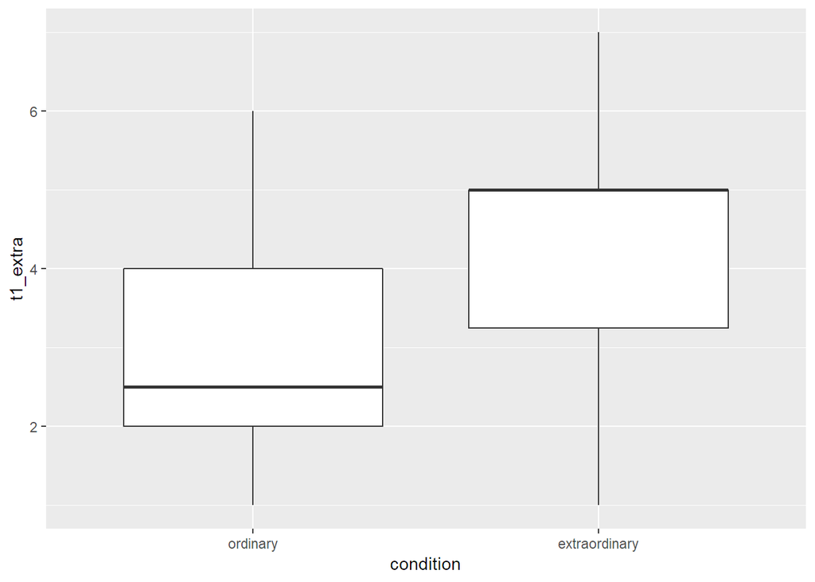

```r
ggplot(zhang_clean, aes(x = condition, y = t1_extra)) +
  geom_boxplot()
```

No outliers in dependent variable for either condition.

#### Normality?

```r
shapiro.test(residuals(t1_extra_aov))
```

```
##
##  Shapiro-Wilk normality test
##
## data:  residuals(t1_extra_aov)
## W = 0.97565, p-value = 0.01928
```

Since *p* = .019, it is less than the significance level and we reject the null hypothesis of this test: the data are not normally distributed. However, remember that the one-way ANOVA is robust and can withstand violations of normality.

Besides, each between-subjects group has a sample size above 30, making this assumption [more-or-less met](http://www2.psychology.uiowa.edu/faculty/mordkoff/GradStats/part%201/I.07%20normal.pdf).

#### Homoscedasticity?

```r
leveneTest(t1_extra ~ condition, data = zhang_clean)
```

```
## Levene's Test for Homogeneity of Variance (center = median)
##        Df F value Pr(>F)
## group   1  0.3641 0.5473
##       128
```

The *F*-value does not exceed the critical values (*p* = .547), so we accept the null hypothesis: the variances are homogenous.

### Extraordinariness Over Time by Condition

Since the design is unorthogonal, the classic `aov()` syntax will return wonky statistics for this repeated measures ANOVA. The output will not match SPSS unless we correct for the unbalanced design. Remember, the uneven cell sizes derive from the unbalanced assignment of participants to the two conditions (i.e., ordinary: n = 64, extraordinary: n = 66).

We will still construct the `aov` object to obtain the sum of squares (to calculate effect size) and the degrees of freedom of the error (for reporting).

```r
# Create analysis of variance
extra_aov <- aov(extra_rating ~ condition*extra_time + Error(subject_id), data = zhang_long)

# Summarize the ANOVA
summary(extra_aov)
```

```
##
## Error: subject_id
##            Df Sum Sq Mean Sq F value  Pr(>F)
## condition   1  78.04   78.04   35.31 2.5e-08 ***
## Residuals 128 282.94    2.21
## ---
## Signif. codes:  0 '***' 0.001 '**' 0.01 '*' 0.05 '.' 0.1 ' ' 1
##
## Error: Within
##                       Df Sum Sq Mean Sq F value   Pr(>F)
## extra_time             1  29.78  29.785   25.63 1.41e-06 ***
## condition:extra_time   1  17.45  17.452   15.02 0.000169 ***
## Residuals            128 148.76   1.162
## ---
## Signif. codes:  0 '***' 0.001 '**' 0.01 '*' 0.05 '.' 0.1 ' ' 1
```

```r
# Tidy output
(extra_tidied <- tidy(extra_aov))
```

```
## # A tibble: 5 x 7
##   stratum    term                   df sumsq meansq statistic      p.value
##   <chr>      <chr>               <dbl> <dbl>  <dbl>     <dbl>        <dbl>
## 1 subject_id condition               1  78.0  78.0       35.3      2.50e-8
## 2 subject_id Residuals             128 283.    2.21      NA       NA
## 3 Within     extra_time              1  29.8  29.8       25.6      1.41e-6
## 4 Within     condition:extra_ti~     1  17.5  17.5       15.0      1.69e-4
## 5 Within     Residuals             128 149.    1.16      NA       NA
```

```r
# Partial eta-squared for main effect of time
extra_tidied$sumsq[3] / (extra_tidied$sumsq[3] + extra_tidied$sumsq[5])
```

```
## [1] 0.1668161
```

```r
# Partial eta-squared for interaction between time and condition
extra_tidied$sumsq[4] / (extra_tidied$sumsq[4] + extra_tidied$sumsq[5])
```

```
## [1] 0.1049985
```

Notice how the main effect on time is *F*(1, 128) = 25.63. This is erroneous.

A solution is found in a call to `car::Anova` by explicitly setting the sum of squares to Type III. We must set the `options()` for contrasts before executing the `Anova()` summary. However, `Anova()` cannot read the ouput of an `aov` object. So, it is necessary to construct a linear mixed-effects model of repeated measures ANOVA using `nlme::lme`.

```r
# Create linear mixed-effects model
extra_lme <- lme(extra_rating ~ condition*extra_time, random = ~1|subject_id, data = zhang_long)

# Print ANOVA summary using type III sum of squares
options(contrasts = c("contr.sum", "contr.poly"))
Anova(extra_lme, type = "III")
```

```
## Analysis of Deviance Table (Type III tests)
##
## Response: extra_rating
##                        Chisq Df Pr(>Chisq)
## (Intercept)          283.759  1  < 2.2e-16 ***
## condition             50.200  1  1.389e-12 ***
## extra_time            39.855  1  2.735e-10 ***
## condition:extra_time  15.017  1  0.0001066 ***
## ---
## Signif. codes:  0 '***' 0.001 '**' 0.01 '*' 0.05 '.' 0.1 ' ' 1
```

Now we need the descriptive statistics for reporting.

```r
# Descriptives for time
zhang_long %>%
  group_by(extra_time) %>%
  summarize(
    n = n(),
    mean = mean(extra_rating),
    sd = sd(extra_rating),
    lower = mean - (1.96 * (sd / sqrt(n))),
    upper = mean + (1.96 * (sd / sqrt(n)))
  )
```

```
## # A tibble: 2 x 6
##   extra_time     n  mean    sd lower upper
##   <fct>      <int> <dbl> <dbl> <dbl> <dbl>
## 1 t1_extra     130  3.55  1.61  3.28  3.83
## 2 t2_extra     130  4.23  1.22  4.02  4.44
```

```r
# Descriptives for simple-effects
zhang_long %>%
  group_by(condition, extra_time) %>%
  summarize(
    n = n(),
    mean = mean(extra_rating),
    sd = sd(extra_rating),
    lower = mean - (1.96 * (sd / sqrt(n))),
    upper = mean + (1.96 * (sd / sqrt(n)))
  )
```

```
## # A tibble: 4 x 7
## # Groups:   condition [?]
##   condition     extra_time     n  mean    sd lower upper
##   <fct>         <fct>      <int> <dbl> <dbl> <dbl> <dbl>
## 1 ordinary      t1_extra      64  2.73  1.42  2.39  3.08
## 2 ordinary      t2_extra      64  3.94  1.25  3.63  4.24
## 3 extraordinary t1_extra      66  4.35  1.38  4.02  4.68
## 4 extraordinary t2_extra      66  4.52  1.14  4.24  4.79
```

#### Outliers?

#### Normality?

#### Homoscedasticity?

#### Sphericity?

### Curiosity Over Time by Condition

Now we rinse and repeat.

```r
# Create aov object
curious_aov <- aov(curious_rating ~ condition*curious_time + Error(subject_id),
                   data = zhang_long)

# Summary of model
summary(curious_aov)
```

```
##
## Error: subject_id
##            Df Sum Sq Mean Sq F value Pr(>F)
## condition   1    2.5   2.473   0.905  0.343
## Residuals 128  349.7   2.732
##
## Error: Within
##                         Df Sum Sq Mean Sq F value Pr(>F)
## curious_time             1   7.45   7.446   5.987 0.0158 *
## condition:curious_time   1   6.37   6.365   5.118 0.0254 *
## Residuals              128 159.19   1.244
## ---
## Signif. codes:  0 '***' 0.001 '**' 0.01 '*' 0.05 '.' 0.1 ' ' 1
```

```r
# Tidy output
(curious_tidied <- tidy(curious_aov))
```

```
## # A tibble: 5 x 7
##   stratum    term                      df  sumsq meansq statistic p.value
##   <chr>      <chr>                  <dbl>  <dbl>  <dbl>     <dbl>   <dbl>
## 1 subject_id condition                  1   2.47   2.47     0.905  0.343
## 2 subject_id Residuals                128 350.     2.73    NA     NA
## 3 Within     curious_time               1   7.45   7.45     5.99   0.0158
## 4 Within     condition:curious_time     1   6.37   6.37     5.12   0.0254
## 5 Within     Residuals                128 159.     1.24    NA     NA
```

```r
# Partial eta-squared for main effect of time
curious_tidied$sumsq[3] / (curious_tidied$sumsq[3] + curious_tidied$sumsq[5])
```

```
## [1] 0.04468552
```

```r
# Partial eta-squared for interaction of time and condition
curious_tidied$sumsq[4] / (curious_tidied$sumsq[4] + curious_tidied$sumsq[5])
```

```
## [1] 0.03844912
```

```r
# Create linear mixed-effects model
curious_lme <- lme(curious_rating ~ condition*curious_time, random = ~1|subject_id,
                   data = zhang_long)

# Print ANOVA summary using type III sum of squares
options(contrasts = c("contr.sum", "contr.poly"))
Anova(curious_lme, type = "III")
```

```
## Analysis of Deviance Table (Type III tests)
##
## Response: curious_rating
##                            Chisq Df Pr(>Chisq)
## (Intercept)            1646.3797  1    < 2e-16 ***
## condition                 0.9051  1    0.34143
## curious_time              6.1574  1    0.01309 *
## condition:curious_time    5.1182  1    0.02368 *
## ---
## Signif. codes:  0 '***' 0.001 '**' 0.01 '*' 0.05 '.' 0.1 ' ' 1
```

```r
# Descriptives for time
zhang_long %>%
  group_by(curious_time) %>%
  summarize(
    n = n(),
    mean = mean(curious_rating),
    sd = sd(curious_rating),
    lower = mean - (1.96 * (sd / sqrt(n))),
    upper = mean + (1.96 * (sd / sqrt(n)))
  )
```

```
## # A tibble: 2 x 6
##   curious_time     n  mean    sd lower upper
##   <fct>        <int> <dbl> <dbl> <dbl> <dbl>
## 1 t1_curious     130  3.99  1.42  3.75  4.24
## 2 t2_curious     130  4.33  1.42  4.09  4.57
```

```r
# Descriptives for simple-effects
zhang_long %>%
  group_by(condition, curious_time) %>%
  summarize(
    n = n(),
    mean = mean(curious_rating),
    sd = sd(curious_rating),
    lower = mean - (1.96 * (sd / sqrt(n))),
    upper = mean + (1.96 * (sd / sqrt(n)))
  )
```

```
## # A tibble: 4 x 7
## # Groups:   condition [?]
##   condition     curious_time     n  mean    sd lower upper
##   <fct>         <fct>        <int> <dbl> <dbl> <dbl> <dbl>
## 1 ordinary      t1_curious      64  3.73  1.39  3.39  4.08
## 2 ordinary      t2_curious      64  4.39  1.48  4.03  4.75
## 3 extraordinary t1_curious      66  4.24  1.40  3.90  4.58
## 4 extraordinary t2_curious      66  4.27  1.36  3.94  4.60
```

#### Outliers?

#### Normality?

#### Homoscedasticity?

#### Sphericity?

### Interest Over Time by Condition

We will run the sample analysis again, creating `aov` and `lme` objects, finding the effect size, and calculating summary statistics.

```r
# Create aov object
interest_aov <- aov(interest_rating ~ condition*interest_time + Error(subject_id),
                    data = zhang_long)

# Summarize the model
summary(interest_aov)
```

```
##
## Error: subject_id
##            Df Sum Sq Mean Sq F value Pr(>F)
## condition   1   0.95  0.9492   0.463  0.498
## Residuals 128 262.60  2.0516
##
## Error: Within
##                          Df Sum Sq Mean Sq F value   Pr(>F)
## interest_time             1  15.51  15.509  25.558 1.45e-06 ***
## condition:interest_time   1   2.70   2.697   4.445    0.037 *
## Residuals               128  77.67   0.607
## ---
## Signif. codes:  0 '***' 0.001 '**' 0.01 '*' 0.05 '.' 0.1 ' ' 1
```

```r
# Tidy output
(interest_tidied <- tidy(interest_aov))
```

```
## # A tibble: 5 x 7
##   stratum    term                   df   sumsq meansq statistic    p.value
##   <chr>      <chr>               <dbl>   <dbl>  <dbl>     <dbl>      <dbl>
## 1 subject_id condition               1   0.949  0.949     0.463    4.98e-1
## 2 subject_id Residuals             128 263.     2.05     NA       NA
## 3 Within     interest_time           1  15.5   15.5      25.6      1.45e-6
## 4 Within     condition:interest~     1   2.70   2.70      4.44     3.70e-2
## 5 Within     Residuals             128  77.7    0.607    NA       NA
```

```r
# Partial eta-squared for main effect of time
interest_tidied$sumsq[3] / (interest_tidied$sumsq[3] + interest_tidied$sumsq[5])
```

```
## [1] 0.166441
```

```r
# Partial eta-squared for interaction between time and condition
interest_tidied$sumsq[4] / (interest_tidied$sumsq[4] + interest_tidied$sumsq[5])
```

```
## [1] 0.03355755
```

```r
# Create linear mixed-effects model
interest_lme <- lme(interest_rating ~ condition*interest_time, random = ~1|subject_id,
                    data = zhang_long)

# Print ANOVA summary using type III sum of squares
options(contrasts = c("contr.sum", "contr.poly"))
Anova(interest_lme, type = "III")
```

```
## Analysis of Deviance Table (Type III tests)
##
## Response: interest_rating
##                             Chisq Df Pr(>Chisq)
## (Intercept)             2505.8159  1  < 2.2e-16 ***
## condition                  0.4627  1    0.49638
## interest_time             25.8813  1  3.631e-07 ***
## condition:interest_time    4.4445  1    0.03501 *
## ---
## Signif. codes:  0 '***' 0.001 '**' 0.01 '*' 0.05 '.' 0.1 ' ' 1
```

```r
# Descriptives for time
zhang_long %>%
  group_by(interest_time) %>%
  summarize(
    n = n(),
    mean = mean(interest_rating),
    sd = sd(interest_rating),
    lower = mean - (1.96 * (sd / sqrt(n))),
    upper = mean + (1.96 * (sd / sqrt(n)))
  )
```

```
## # A tibble: 2 x 6
##   interest_time     n  mean    sd lower upper
##   <fct>         <int> <dbl> <dbl> <dbl> <dbl>
## 1 t1_interest     130  4.20  1.12  4.01  4.40
## 2 t2_interest     130  4.69  1.19  4.49  4.90
```

```r
# Descriptives for simple-effects
zhang_long %>%
  group_by(condition, interest_time) %>%
  summarize(
    n = n(),
    mean = mean(interest_rating),
    sd = sd(interest_rating),
    lower = mean - (1.96 * (sd / sqrt(n))),
    upper = mean + (1.96 * (sd / sqrt(n)))
  )
```

```
## # A tibble: 4 x 7
## # Groups:   condition [?]
##   condition     interest_time     n  mean    sd lower upper
##   <fct>         <fct>         <int> <dbl> <dbl> <dbl> <dbl>
## 1 ordinary      t1_interest      64  4.04  1.09  3.77  4.31
## 2 ordinary      t2_interest      64  4.73  1.24  4.43  5.04
## 3 extraordinary t1_interest      66  4.36  1.13  4.09  4.64
## 4 extraordinary t2_interest      66  4.65  1.14  4.38  4.93
```

A third repeated measures ANOVA used the composite interest score as the continuous dependent variable. Once again, time was a main effect, *F*(1, 128) = 25.88, *p* < .001, $\eta_p^2 = .17$; participants tended to be more interested upon reading their letter, at Time 2 (*M* = 4.69, *SD* = 1.19, 95% CI = [4.49, 4.90]), than they had anticipated, at Time 1 (*M* = 4.20, *SD* = 1.12, 95% CI = [4.01, 4.40]). The interaction of time and type of event was again significant, *F*(1, 128) = 4.44, *p* = .04, $\eta_p^2 = .03$.

#### Outliers?

#### Normality?

#### Homoscedasticity?

#### Sphericity?

### Visualize

## Communicate

A manipulation check at Time 1 revealed that participants assigned to the extraordinary condition perceived their experience with a lover to be more extraordinary (*M* = 4.35, *SD* = 1.38, 95% CI = [4.02, 4.68]) than those in the ordinary condition (*M* = 2.73, *SD* = 1.42, 95% CI = [2.39, 3.08]), *F*(1, 128) = 43.43, *p* < .001, $\eta_p^2 = .25$.

*Interest*. A third repeated measures ANOVA used the composite interest score as the continuous dependent variable. Once again, time was a main effect, *F*(1, 128) = 25.88, *p* < .001, $\eta_p^2 = .17$; participants tended to be more interested upon reading their letter, at Time 2 (*M* = 4.69, *SD* = 1.19, 95% CI = [4.49, 4.90]), than they had anticipated, at Time 1 (*M* = 4.20, *SD* = 1.12, 95% CI = [4.01, 4.40]). The interaction of time and type of event was again significant, *F*(1, 128) = 4.44, *p* = .04, $\eta_p^2 = .03$.

# Acknowledgements

I am thankful for my advisor, Dr. Brandt A. Smith for introducing me to R, JASP, and OSL. The discipline of psychology is advocating for preregistered, open materials. His encouragement to utilize open data and open source software has positioned me in the middle of the reproducible movement.

I would still be clicking checkboxes and dropdowns to analyze data if it were not for [DataCamp](https://www.datacamp.com), [Rose Maier](https://rstudio-pubs-static.s3.amazonaws.com/65059_586f394d8eb84f84b1baaf56ffb6b47f.html), [Alboukadel Kassambara](http://www.sthda.com/english/wiki/r-software), [Jonathan Baron](https://www.sas.upenn.edu/~baron/from_cattell/rpsych/rpsych.html#htoc60), and the team behind [personality-project](http://personality-project.org/r/r.guide.html#withinone).

## Dependencies

This activity was completed using RStudio.